# GroupC_HW4

### Polynomial Regression

Using `horsepower` as the only predictor.

By doing 8-fold cross-validation, we want to find out which degree of polynomial fits the data best without overfitting.

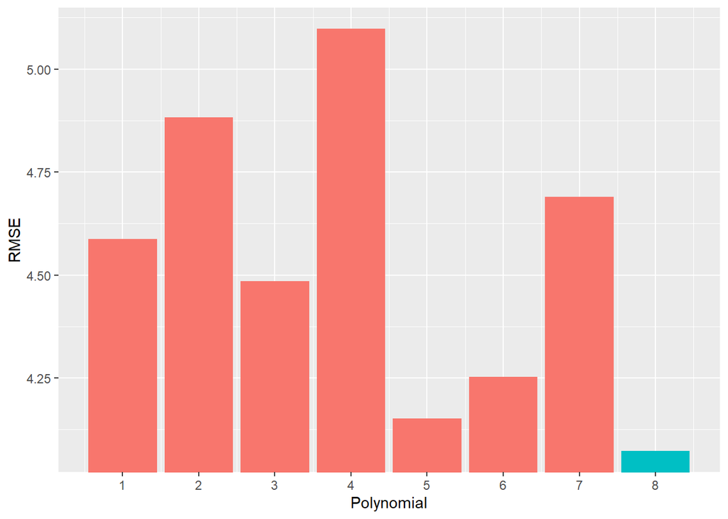

```r
# Selecting the best fit by K-fold cross validation
library(ggplot2)

folds <- sample(rep(1:8, nrow(Auto)/8))
errors <- matrix(NA, 8, 8)
models <- list()

for (k in 1:8) {
    for (i in 1:8) {
        model <- lm(mpg ~ poly(horsepower,i), data = Auto[folds != i,])
        pred <- predict(model, Auto[folds == i,])
        resid <- (Auto$mpg[folds==i] - pred)^2
        errors[k, i] <- sqrt(mean(resid))
    }
}
errors <- apply(errors, 2, mean)

data_frame(RMSE = errors) %>%
    mutate(Polynomial = row_number()) %>%
    ggplot(aes(Polynomial, RMSE, fill = Polynomial == which.min(errors))) +
    geom_col() +
    scale_x_continuous(breaks = 1:8) +
    guides(fill = FALSE) +
    coord_cartesian(ylim = c(min(errors), max(errors)))
```

```r
optimal_degree <- which.min(errors)
```

The optimal polynomial degree is:

```r
optimal_degree
```

```
## [1] 8
```

Let’s fit a polynomial regression model with this degree.

```r
poly <- lm(mpg ~ poly(horsepower, optimal_degree), data = Auto)
summary(poly)
```

```
##
## Call:
## lm(formula = mpg ~ poly(horsepower, optimal_degree), data = Auto)
##
## Residuals:
##      Min       1Q   Median       3Q      Max
## -15.5939  -2.5657  -0.2684   2.2188  15.1306
##
## Coefficients:
##                                    Estimate Std. Error t value Pr(>|t|)
## (Intercept)                         23.4459     0.2172 107.953  < 2e-16 ***
## poly(horsepower, optimal_degree)1 -120.1377     4.3001 -27.939  < 2e-16 ***
## poly(horsepower, optimal_degree)2   44.0895     4.3001  10.253  < 2e-16 ***
## poly(horsepower, optimal_degree)3   -3.9488     4.3001  -0.918  0.35903
## poly(horsepower, optimal_degree)4   -5.1878     4.3001  -1.206  0.22839
## poly(horsepower, optimal_degree)5   13.2722     4.3001   3.086  0.00217 **
## poly(horsepower, optimal_degree)6   -8.5462     4.3001  -1.987  0.04758 *
## poly(horsepower, optimal_degree)7    7.9806     4.3001   1.856  0.06423 .
## poly(horsepower, optimal_degree)8    2.1727     4.3001   0.505  0.61366
## ---
## Signif. codes:  0 '***' 0.001 '**' 0.01 '*' 0.05 '.' 0.1 ' ' 1
##
## Residual standard error: 4.3 on 383 degrees of freedom
## Multiple R-squared:  0.7027, Adjusted R-squared:  0.6965
## F-statistic: 113.1 on 8 and 383 DF,  p-value: < 2.2e-16
```

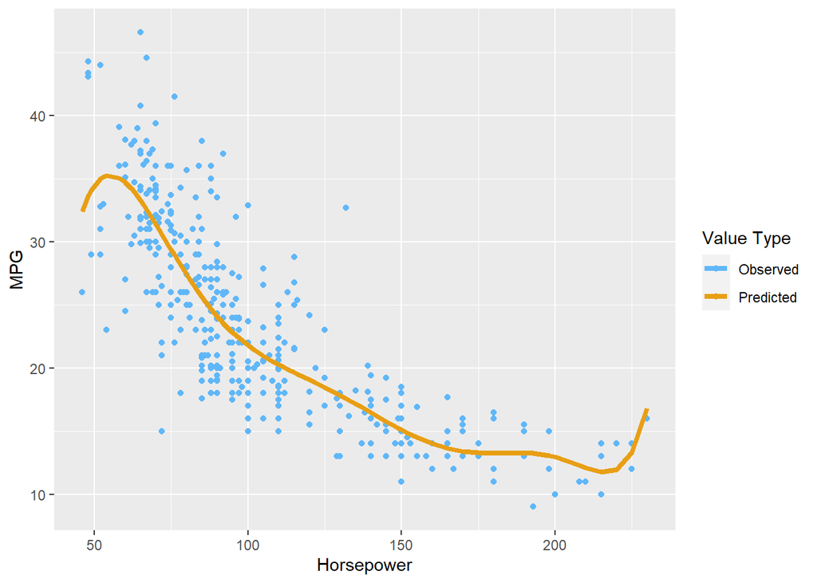

```r
Auto %>%
    mutate(Predictions = predict(poly, Auto)) %>%
    ggplot() + xlab('Horsepower') + ylab('MPG') +
    geom_point(aes(horsepower, mpg, col = 'blue')) +
    geom_line(aes(horsepower, Predictions, col = 'red'), size = 1.5) +
    scale_color_manual(name = 'Value Type',
                       labels = c('Observed', 'Predicted'),
                       values = c('#60B7F8', '#E89F15'))
```

### Splines

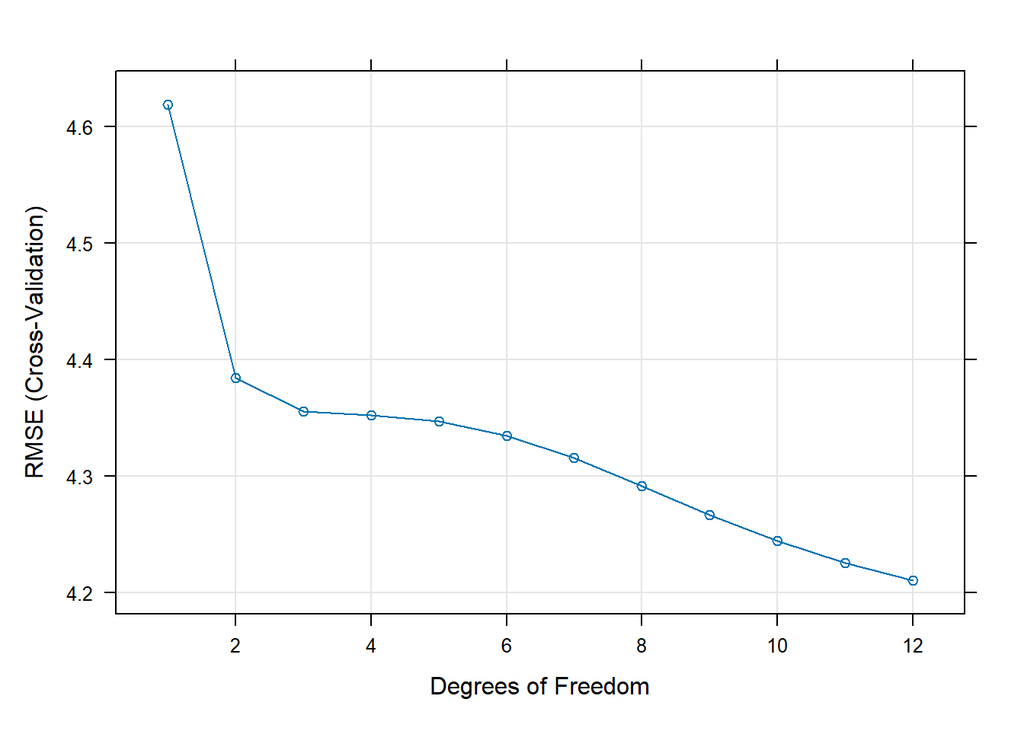

```r
# Using Caret package to ease model selection
library(caret)

spline <- train(mpg ~ displacement, data = Auto,
                method = 'gamSpline',
                trControl = trainControl(method = 'cv', number = 8),
                tuneGrid = expand.grid(df = seq(1, 12, 1)))
linear <- train(mpg ~ displacement, data = Auto, method = 'lm',
                trControl = trainControl(method = 'cv', number = 8))
plot(spline)
```

The cross-validation leads us to choose a spline basis with 12 degrees of freedom.

```r
anova(linear$finalModel, spline$finalModel)
```

```
## Analysis of Variance Table
##
## Model 1: .outcome ~ displacement
## Model 2: .outcome ~ s(displacement, df = 12)
##   Res.Df    RSS Df Sum of Sq      F    Pr(>F)
## 1    390 8378.8
## 2    379 6629.3 11    1749.5 9.0928 1.828e-14 ***
## ---
## Signif. codes:  0 '***' 0.001 '**' 0.01 '*' 0.05 '.' 0.1 ' ' 1
```

The Spline model fits better the data. It decreases the residual sum of squares by 20% and its p-value is close to zero. Therefore, we can say with good confidence that the relationship is non-linear.

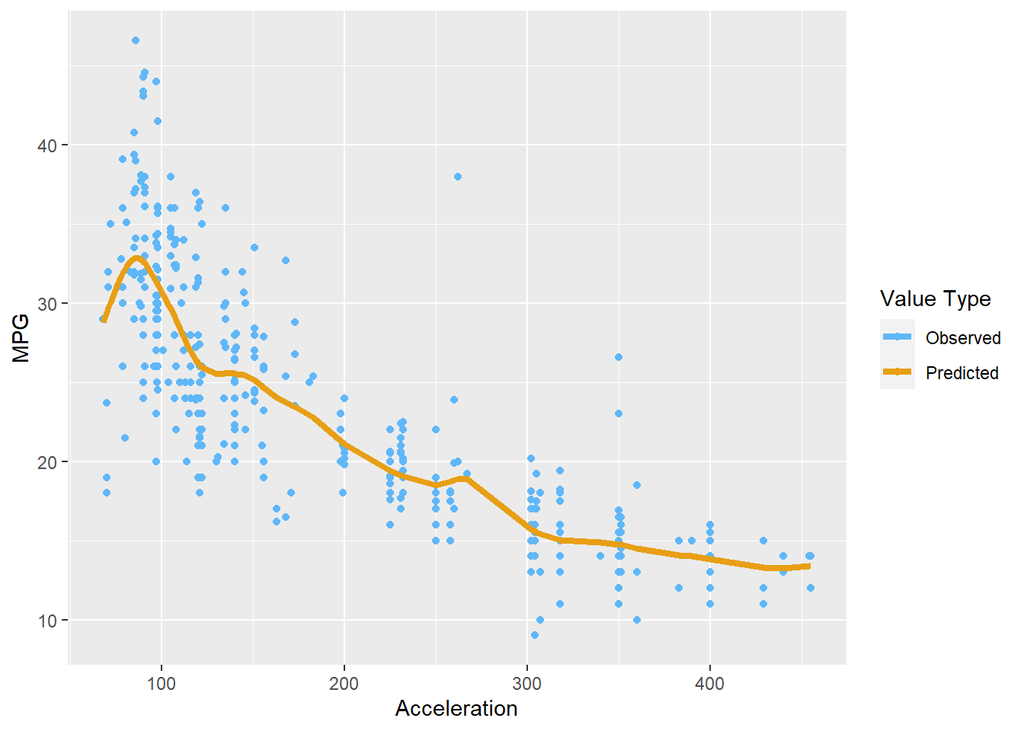

```r
Auto %>%
    mutate(pred = predict(spline, Auto)) %>%
    ggplot() +
    geom_point(aes(displacement, mpg, col = 'blue')) +
    geom_line(aes(displacement, pred, col = 'red'), size = 1.5) +
    scale_color_manual(name = 'Value Type',
                       labels = c('Observed', 'Predicted'),
                       values = c('#60B7F8', '#E89F15')) +
    labs(x = 'Acceleration', y = 'MPG')
```

### Generalized Adaptive Model

```r
# Crossvalidating again via Caret

gam <- train(mpg ~ horsepower  +
               weight +
               displacement +
               acceleration +
               year, data = Auto,
               method = 'gam',
               trControl = trainControl(method = 'cv', number = 10))

linear_2 <- train(mpg ~ horsepower  +
                    weight +
                    displacement +
                    acceleration +
                    year +
                    cylinders, data = Auto,
                    method = 'lm',
                    trControl = trainControl(method = 'cv', number = 10))

summary(gam$finalModel)
```

```
##
## Family: gaussian
## Link function: identity
##
## Formula:
## .outcome ~ s(year) + s(displacement) + s(horsepower) + s(acceleration) +
##     s(weight)
##
## Parametric coefficients:
##             Estimate Std. Error t value Pr(>|t|)
## (Intercept)  23.4459     0.1342   174.8   <2e-16 ***
## ---
## Signif. codes:  0 '***' 0.001 '**' 0.01 '*' 0.05 '.' 0.1 ' ' 1
##
## Approximate significance of smooth terms:
##                   edf Ref.df      F  p-value
## s(year)         8.427  8.903 47.705  < 2e-16 ***
## s(displacement) 1.753  2.184  3.171 0.045035 *
## s(horsepower)   2.181  2.779  7.851 0.000223 ***
## s(acceleration) 2.382  3.074  2.246 0.088231 .
## s(weight)       2.545  3.219 18.996  < 2e-16 ***
## ---
## Signif. codes:  0 '***' 0.001 '**' 0.01 '*' 0.05 '.' 0.1 ' ' 1
##
## R-sq.(adj) =  0.884   Deviance explained = 88.9%
## GCV = 7.4006  Scale est. = 7.0554    n = 392
```

```r
anova(linear_2$finalModel, gam$finalModel)
```

```
## Analysis of Variance Table
##
## Model 1: .outcome ~ horsepower + weight + displacement + acceleration +
##     year + cylinders
## Model 2: .outcome ~ s(year) + s(displacement) + s(horsepower) + s(acceleration) +
##     s(weight)
##   Res.Df    RSS     Df Sum of Sq     F    Pr(>F)
## 1 385.00 4543.3
## 2 373.71 2636.7 11.288    1906.7 23.94 < 2.2e-16 ***
## ---
## Signif. codes:  0 '***' 0.001 '**' 0.01 '*' 0.05 '.' 0.1 ' ' 1
```

The GAM model fits the data better than the linear model. It decreases the residual sum of squares by 42% and its p-value is close to zero. Therefore, we can say with good confidence that the relationship between the response and the covariates is non-linear.

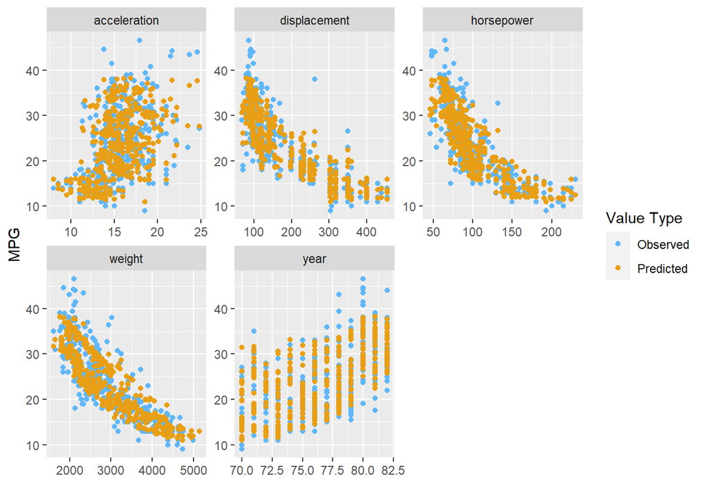

```r
Auto %>%
    mutate(pred = predict(gam, Auto)) %>%
    gather(variable, value,
           weight, horsepower,
           displacement, acceleration,
           year) %>%
    ggplot() +
    labs(x = '', y = 'MPG') +
    geom_point(aes(value, mpg, col = 'blue')) +
    geom_point(aes(value, pred, col = 'red'), size = 1.5) +
    scale_color_manual(name = 'Value Type',
                       labels = c('Observed', 'Predicted'),
                       values = c('#60B7F8', '#E89F15')) +
    facet_wrap(~variable, scales = 'free')
```

## Exercise 9

This question uses the variables dis (the weighted mean of distances to five Boston employment centers) and nox (nitrogen oxides concen- tration in parts per 10 million) from the Boston data. We will treat dis as the predictor and nox as the response.

1. Use the poly() function to fit a cubic polynomial regression to predict nox using dis. Report the regression output, and plot the resulting data and polynomial fits.

```r
library(MASS)
library(ggplot2)
library(splines)

data(Boston)

fit = lm(nox ~ poly(dis, 3), data = Boston)

summary(fit)
```

```
##
## Call:
## lm(formula = nox ~ poly(dis, 3), data = Boston)
##
## Residuals:
##       Min        1Q    Median        3Q       Max
## -0.121130 -0.040619 -0.009738  0.023385  0.194904
##
## Coefficients:
##                Estimate Std. Error t value Pr(>|t|)
## (Intercept)    0.554695   0.002759 201.021  < 2e-16 ***
## poly(dis, 3)1 -2.003096   0.062071 -32.271  < 2e-16 ***
## poly(dis, 3)2  0.856330   0.062071  13.796  < 2e-16 ***
## poly(dis, 3)3 -0.318049   0.062071  -5.124 4.27e-07 ***
## ---
## Signif. codes:  0 '***' 0.001 '**' 0.01 '*' 0.05 '.' 0.1 ' ' 1
##
## Residual standard error: 0.06207 on 502 degrees of freedom
## Multiple R-squared:  0.7148, Adjusted R-squared:  0.7131
## F-statistic: 419.3 on 3 and 502 DF,  p-value: < 2.2e-16
```

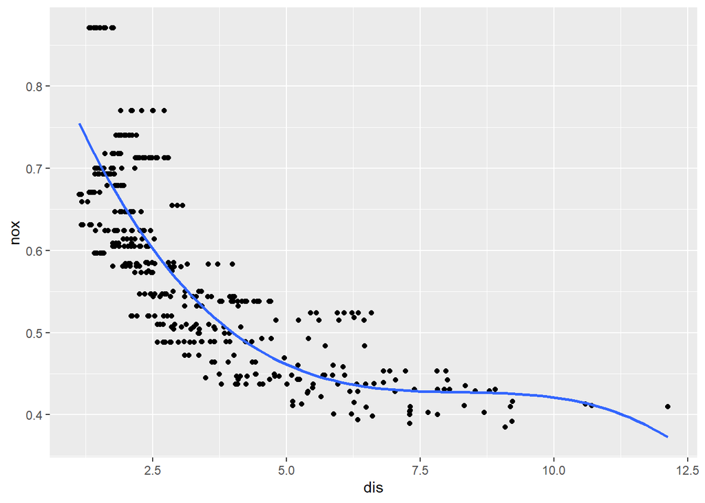

```r
ggplot(Boston, aes(dis, nox)) + geom_point() +
  stat_smooth(method = "lm", formula = y ~ poly(x, 3), se = FALSE)
```

(b) Plot the polynomial fits for a range of different polynomial de- grees (say, from 1 to 10), and plot the associated residual sum of squares.

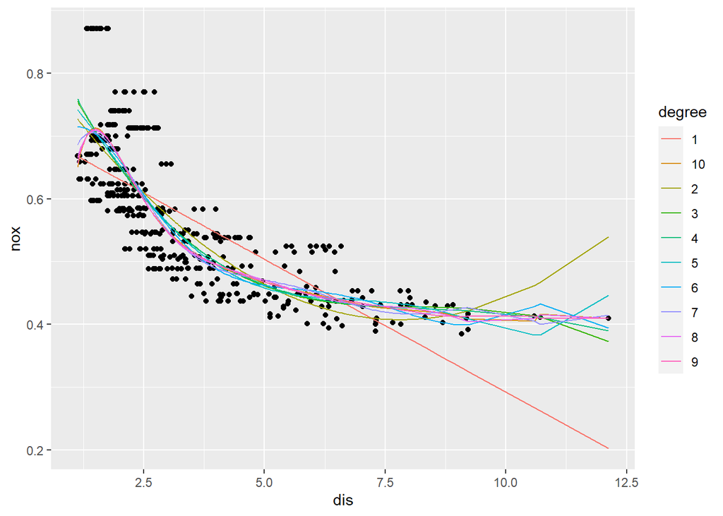

```r
df = data.frame("nox"=numeric(),
                "dis"=numeric(),
                "degree"=factor())
rss = vector(mode="numeric", length=10L)

for (i in 1:10) {
  fit = lm(nox ~ poly(dis, i), data = Boston)

  df1 = data.frame("nox"=fit$fitted.values,
                   "dis"=Boston$dis,
                   "degree"=paste0(i))

  df = rbind(df, df1)
  rss[i] = sum(resid(fit)^2)
}

ggplot(data=Boston, aes(x=dis, y=nox)) + geom_point() +
  geom_line(data=df, aes(x=dis, y=nox, color=degree))
```

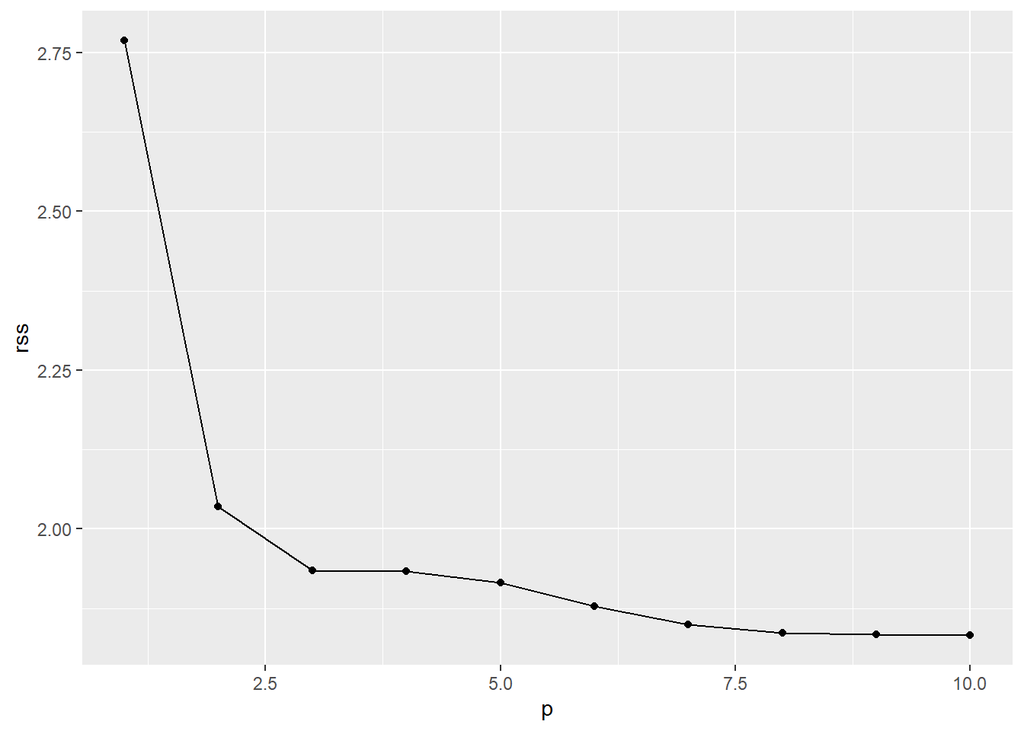

```r
df1 = data.frame("rss"=rss,
                 "p"=1:10)
df1 %>% ggplot(aes(x=p, y=rss)) + geom_point() + geom_line()
```

3. Perform cross-validation or another approach to select the opti- mal degree for the polynomial, and explain your results.

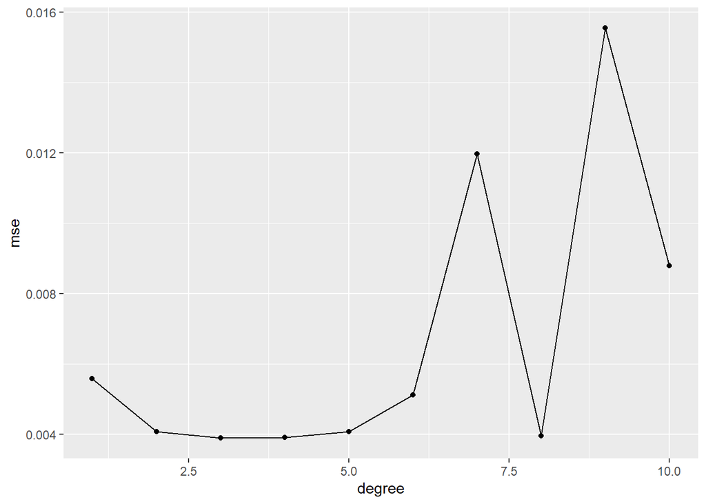

```r
library(cv)

mse = vector(mode="numeric", length=10L)
for (p in 1:10){
  fit = lm(nox ~ poly(dis, p), data=Boston)
  mse[p] = cv(fit)$`CV crit`

}
df = data.frame("mse"=mse,
                "degree"=1:10)

df %>% ggplot(aes(x=degree, y=mse)) + geom_line() + geom_point()
```

The MSE decreases at first and reaches the minimum for a polynomial of degree $p=3$. With polynomials of degree 6 and above the model fails to predict the values at the left boundary of X (see the previous plots), thus increasing noticeably the MSE.

4. Use the bs() function to fit a regression spline to predict nox using dis. Report the output for the fit using four degrees of freedom. How did you choose the knots? Plot the resulting fit.

```r
fit = lm(nox ~ bs(dis, df=4), data = Boston)

summary(fit)
```

```
##
## Call:
## lm(formula = nox ~ bs(dis, df = 4), data = Boston)
##
## Residuals:
##       Min        1Q    Median        3Q       Max
## -0.124622 -0.039259 -0.008514  0.020850  0.193891
##
## Coefficients:
##                  Estimate Std. Error t value Pr(>|t|)
## (Intercept)       0.73447    0.01460  50.306  < 2e-16 ***
## bs(dis, df = 4)1 -0.05810    0.02186  -2.658  0.00812 **
## bs(dis, df = 4)2 -0.46356    0.02366 -19.596  < 2e-16 ***
## bs(dis, df = 4)3 -0.19979    0.04311  -4.634 4.58e-06 ***
## bs(dis, df = 4)4 -0.38881    0.04551  -8.544  < 2e-16 ***
## ---
## Signif. codes:  0 '***' 0.001 '**' 0.01 '*' 0.05 '.' 0.1 ' ' 1
##
## Residual standard error: 0.06195 on 501 degrees of freedom
## Multiple R-squared:  0.7164, Adjusted R-squared:  0.7142
## F-statistic: 316.5 on 4 and 501 DF,  p-value: < 2.2e-16
```

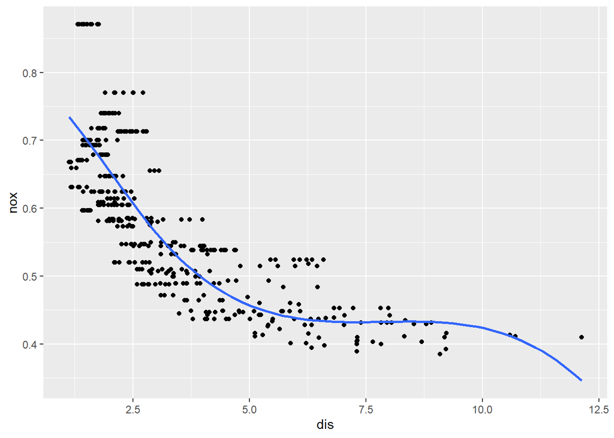

```r
# The knots are picked by default by the bs() function at quantiles 0.2, 0.4, 0.6, 0.8 of X.
ggplot(Boston, aes(dis, nox)) + geom_point() +
  stat_smooth(method = "lm", formula = y ~ bs(x, df=4), se = FALSE)
```

(e) Now fit a regression spline for a range of degrees of freedom, and plot the resulting fits as well as the resulting RSS. Describe the results obtained.

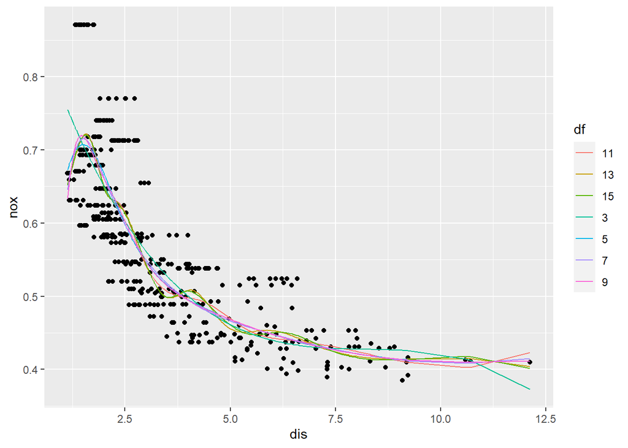

```r
df = data.frame("nox"=numeric(),
                "dis"=numeric(),
                "df"=factor())
rss = c()

for (i in seq(3,15,2)) {
  fit = lm(nox ~ bs(dis, df=i), data = Boston)

  df1 = data.frame("nox"=fit$fitted.values,
                   "dis"=Boston$dis,
                   "df"=paste0(i))

  df = rbind(df, df1)
  rss = c(rss, sum(resid(fit)^2))
}

ggplot(data=Boston, aes(x=dis, y=nox)) + geom_point() +
  geom_line(data=df, aes(x=dis, y=nox, color=df))
```

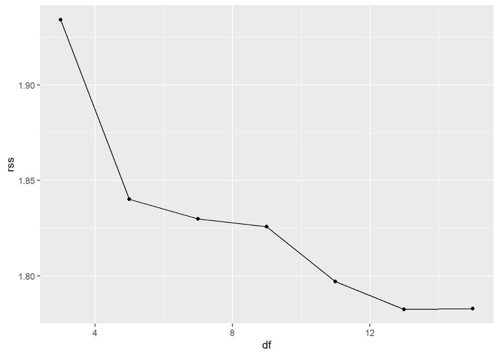

```r
df1 = data.frame("rss"=rss,
                 "df"=seq(3,15,2))
df1 %>% ggplot(aes(x=df, y=rss)) + geom_point() + geom_line()
```

An excessive number of degrees of freedom results in an overfit of the data (again, on the left bound of X), and unnaturally wiggly regression lines.

6. Perform cross-validation or another approach in order to select the best degrees of freedom for a regression spline on this data. Describe your results.

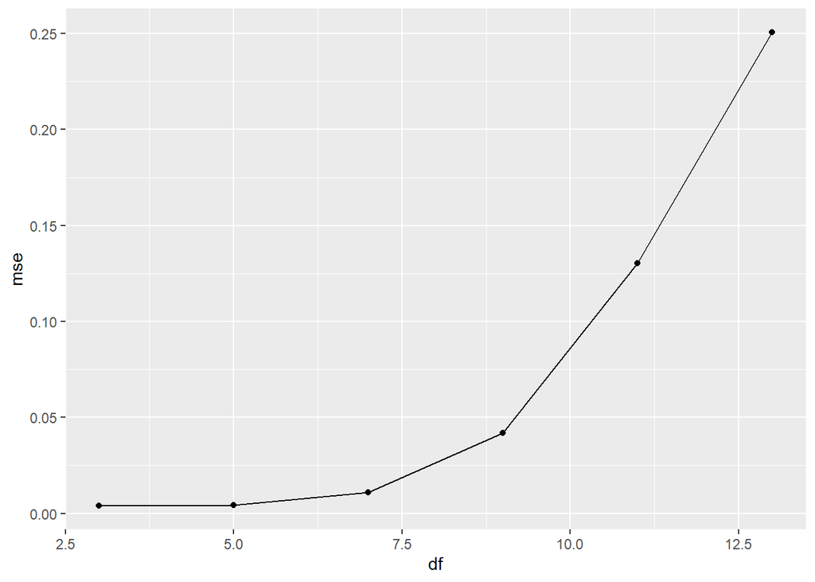

```r
mse = c()
for (p in seq(3,14,2)){
  fit = lm(nox ~ poly(dis, p), data=Boston)
  mse = c(mse, cv(fit)$`CV crit`)

}
df = data.frame("mse"=mse,
                "df"=seq(3,14,2))

df %>% ggplot(aes(x=df, y=mse)) + geom_line() + geom_point()
```

## Exercise 10

This question relates to the College data set. (a) Using out-of-state tuition as the response and the other variables as the predictors, perform forward stepwise selection in order to identify a satisfactory model that uses just a subset of the predictors. (b) Divide the observations into a training set and a test set. Fit a GAM on the training data, using out-of-state tuition as the response and the features selected in the previous step as the predictors. Plot the results, and explain your findings. (c) Evaluate the model obtained on the test set, and explain the results obtained. (d) For which variables, if any, is there evidence of a non-linear relationship with the response?

**Solution**

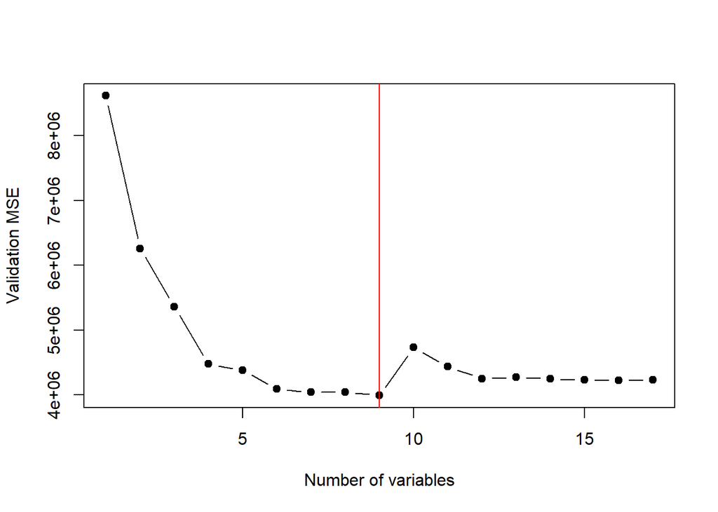

```r
library(ISLR)
library("leaps")
library("glmnet")

set.seed(0)

# Divide the dataset into training (1) and test (2)
dataset_part <- sample(1:2, nrow(College), replace = T, prob = c(0.8, 0.2))

p <- ncol(College) - 1

# Fit subsets of various sizes:
regfit.forward <- regsubsets(Outstate ~ ., data = College[dataset_part == 1, ], nvmax = p, method = "forward")

# Test the trained models on the test set:
test.mat <- model.matrix(Outstate ~ ., data = College[dataset_part == 2, ])
test.errors <- rep(NA, p)
for (i in 1:p) {
    coefi <- coef(regfit.forward, id = i)
    pred <- test.mat[, names(coefi)] %*% coefi
    test.errors[i] <- mean((College$Outstate[dataset_part == 2] - pred)^2)
}

k <- which.min(test.errors)

plot(test.errors, xlab = "Number of variables", ylab = "Validation MSE", pch = 19, type = "b")
abline(v = k, col = "red")
```

```r
k
```

```
## [1] 9
```

It looks like the best model is the one with 9 predictors, given by the validation errors.

The variables (and their coefficients) are:

```r
coef(regfit.forward, id = k)
```

```
##   (Intercept)    PrivateYes        Accept    Room.Board      Personal
## -2.346889e+03  2.864115e+03  8.277223e-02  9.031112e-01 -3.443404e-01
##      Terminal     S.F.Ratio   perc.alumni        Expend     Grad.Rate
##  4.349970e+01 -6.302943e+01  4.080851e+01  1.871342e-01  2.615843e+01
```

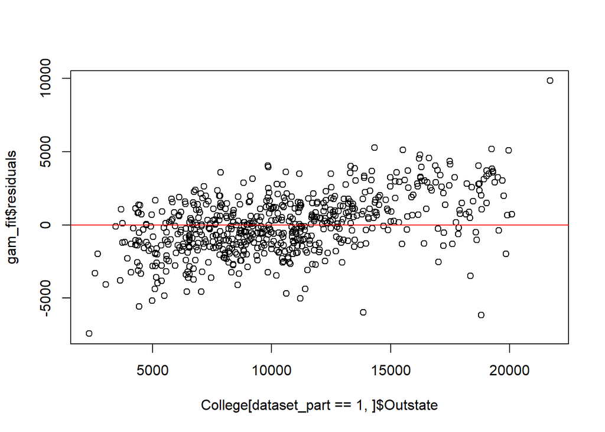

```r
library(gam)

gam_fit <- gam(Outstate ~ Private + Accept + Room.Board + Personal + Terminal + S.F.Ratio + perc.alumni + Expend + Grad.Rate, data = College[dataset_part == 1, ])
plot(College[dataset_part == 1, ]$Outstate, gam_fit$residuals)
abline(h = 0, col = "red")
```

```r
# Predict the GAM performance on the test dataset:
y_hat <- predict(gam_fit, newdata = College[dataset_part == 2, ])
RMSE <- mean((College[dataset_part == 2, ]$Outstate - y_hat)^2)

cat("RMSE of the GAM model:", RMSE, ", RMSE of the best subset model:", test.errors[k], "\n")
```

```
## RMSE of the GAM model: 3992328 , RMSE of the best subset model: 3992328
```

Surprisingly, the GAM model and the best subset model have the same RMSE.

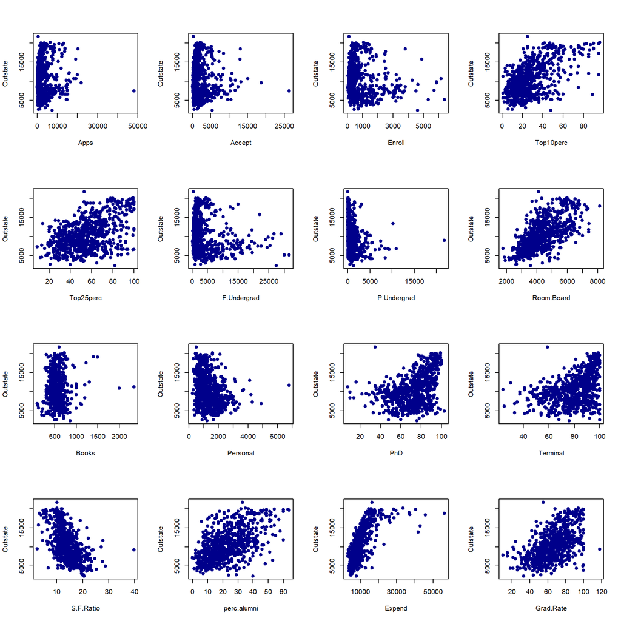

```r
par(mfrow = c(3, 3))

par(mfrow = c (4, 4))
for(var in names(College)){
  if(var != "Outstate" && var != "Private") # Avoid plotting the response variable and the categorical variables
    plot(College[, var], College$Outstate, xlab = var, ylab = "Outstate", pch = 19, col = "blue4")
}
```

It’s not very clear which variables are in a non-linear relationship with the response due to the high variability of the data. However, some of them show some non-linear trends.

## Exercise 11

In Section 7.7, it was mentioned that GAMs are generally fit using a backfitting approach. The idea behind backfitting is actually quite simple. We will now explore backfitting in the context of multiple linear regression. Suppose that we would like to perform multiple linear regression, but we do not have software to do so. Instead, we only have software to perform simple linear regression. Therefore, we take the following it erative approach: we repeatedly hold all but one coefficient estimate fixed at its current value, and update only that coefficient estimate using a simple linear regression. The process is continued until convergence — that is, until the coefficient estimates stop changing. We now try this out on a toy example.

1. Generate a response Y and two predictors $X_1$ and $X_2$, with$n = 100$.
2. Initialize ˆβ1 to take on a value of your choice. It does not matter what value you choose.
3. Keeping $\hat{\beta}_1$ fixed, fit the model $Y − \hat{\beta}_1X_1 = \hat{\beta}_0 + \hat{\beta}_2X^2 + e$. You can do this as follows:

```r
a = y - beta1 * x1
beta2 = lm(a∼x2) $coef[2]
```

4. Keeping $\hat{\beta}_2$ fixed, fit the model $Y − \hat{\beta}_2X^2 = \hat{\beta}_0 + \hat{\beta}_1X^1 + e$. You can do this as follows:

```r
a = y - beta2 * x2
beta1 = lm(a∼x1) $coef[2]
```

5. Write a for loop to repeat (c) and (d) 1000 times. Report the estimates of $\hat{\beta}_0$, $\hat{\beta}_1$, and $\hat{\beta}_2$ at each iteration of the for loop. Create a plot in which each of these values is displayed, with ˆβ0, $\hat{\beta}_1$, and $\hat{\beta}_2$ each shown in a different color.
6. Compare your answer in (e) to the results of simply performing multiple linear regression to predict $Y$ using $X_1$ and $X_2$. Use the abline() function to overlay those multiple linear regression coefficient estimates on the plot obtained in (e).
7. On this dataset, how many backfitting iterations were required in order to obtain a “good” approximation to the multiple regression coefficient estimates?

**Solution**

The following model is considered for $Y$:
$$Y=18 +
0.8 X_1 − 20 X_2 + \epsilon \\ X_1 \sim N(0,1) \\ X_2 \sim N(0,1) \\
\epsilon \sim N(0,1)$$

```r
library(dplyr)
library(ggplot2)
library(gridExtra)

set.seed(591)
x1 <- rnorm(100)
x2 <- rnorm(100)
eps <- rnorm(100)

y <- 18 + 0.8*x1 - 20*x2 + eps
```

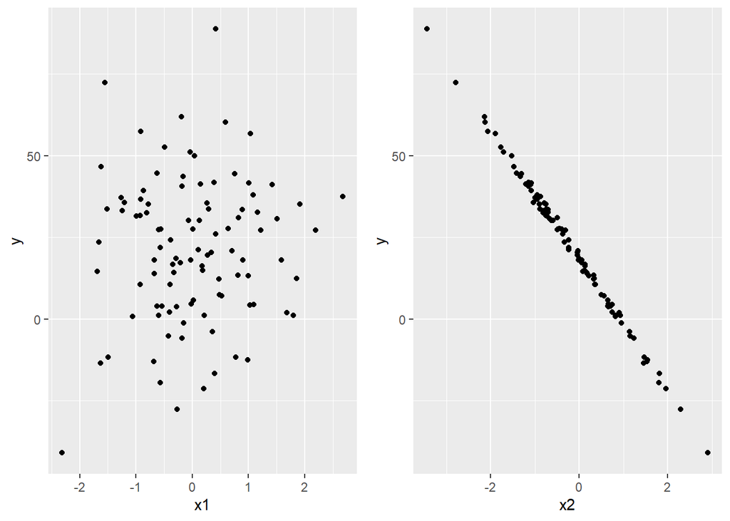

```r
g1 <- data.frame(x1, x2, y) %>%
  ggplot(aes(x1, y)) +
  geom_point()

g2 <- data.frame(x1, x2, y) %>%
  ggplot(aes(x2, y)) +
  geom_point()

grid.arrange(g1, g2, ncol = 2)
```

$\hat{\beta}_1$ is initialized to 1.

```r
beta1 <- 1
```

```r
a = y - beta1 * x1
beta2 = lm(a~x2)$coef[2]
beta2
```

```
##       x2
## -19.9715
```

```r
r1 = y - beta2 * x2
beta1 = lm(r1 ~ x1)$coef[2]
beta1
```

```
##        x1
## 0.9348787
```

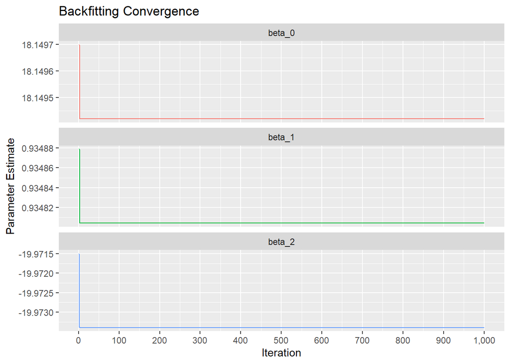

```r
library(tidyverse)

beta_1_init <- 1

beta_0 <- c()
beta_1 <- c()
beta_2 <- c()

# beta_2:
r2 <- y - beta_1_init * x1
beta_2[1] <- lm(r2 ~ x2)$coef[2]

# beta_1:
r1 <- y - beta_2[1] * x2
lm_coef <- lm(r1 ~ x1)$coef
beta_1[1] <- lm_coef[2]

# beta_0:
beta_0[1] <- lm_coef[1]


for (i in 2:1000) {
  r2 <- y - beta_1[i-1] * x1
  beta_2[i] <- lm(r2 ~ x2)$coef[2]

  r1 <- y - beta_2[i-1] * x2
  lm_coef <- lm(r1 ~ x1)$coef
  beta_1[i] <- lm_coef[2]

  beta_0[i] <- lm_coef[1]
}

data.frame(iteration = 1:1000, beta_0, beta_1, beta_2) %>%
  pivot_longer(-iteration, names_to = "coefficient", values_to = "estimate") %>%
  ggplot(aes(x = iteration, y = estimate, col = factor(coefficient))) +
  geom_line() +
  scale_x_continuous(breaks = seq(0, 1000, 100), labels = scales::comma_format()) +
  facet_wrap(coefficient ~ ., scales = "free_y", nrow = 3) +
  theme(legend.position = "none") +
  labs(title = "Backfitting Convergence",
       x = "Iteration",
       y = "Parameter Estimate")
```

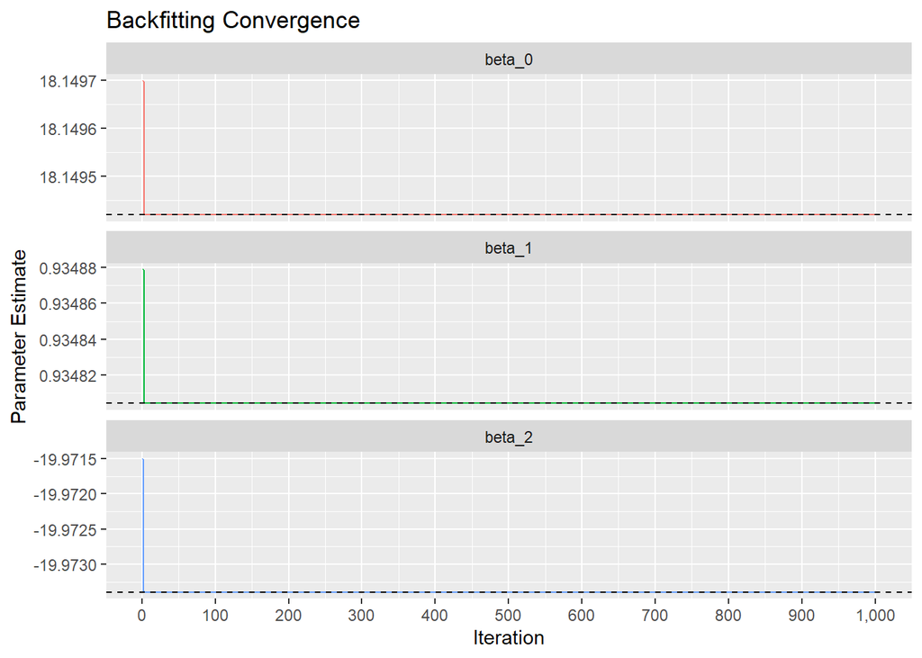

```r
lm_coef <- lm(y ~ x1 + x2)$coefficients

data.frame(iteration = 1:1000, beta_0, beta_1, beta_2) %>%
  pivot_longer(-iteration, names_to = "coefficient", values_to = "estimate") %>%
  ggplot(aes(x = iteration, y = estimate, col = factor(coefficient))) +
  geom_line() +
  geom_hline(data = data.frame(yint = lm_coef[1], coefficient = "beta_0"), aes(yintercept = yint), linetype = "dashed") +
  geom_hline(data = data.frame(yint = lm_coef[2], coefficient = "beta_1"), aes(yintercept = yint), linetype = "dashed") +
  geom_hline(data = data.frame(yint = lm_coef[3], coefficient = "beta_2"), aes(yintercept = yint), linetype = "dashed") +
  scale_x_continuous(breaks = seq(0, 1000, 100), labels = scales::comma_format()) +
  facet_wrap(coefficient ~ ., scales = "free_y", nrow = 3) +
  theme(legend.position = "none") +
  labs(title = "Backfitting Convergence",
       x = "Iteration",
       y = "Parameter Estimate")
```

```r
data.frame(simple_reg = c(beta_0[1000], beta_1[1000], beta_2[1000]), multiple_reg = as.numeric(lm_coef))
```

```
##    simple_reg multiple_reg
## 1  18.1494196   18.1494196
## 2   0.9348044    0.9348044
## 3 -19.9733965  -19.9733965
```

The coefficients obtained from backfitting are exactly the same as the coefficients obtained from multiple linear regression.

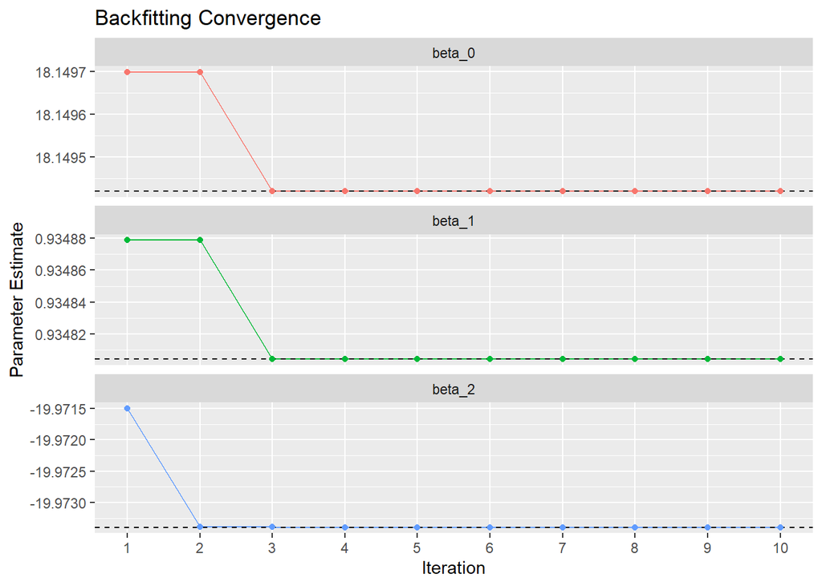

```r
data.frame(iteration = 1:1000, beta_0, beta_1, beta_2) %>%
  pivot_longer(-iteration, names_to = "coefficient", values_to = "estimate") %>%
  ggplot(aes(x = iteration, y = estimate, col = factor(coefficient))) +
  geom_line() +
  geom_hline(data = data.frame(yint = lm_coef[1], coefficient = "beta_0"), aes(yintercept = yint), linetype = "dashed") +
  geom_hline(data = data.frame(yint = lm_coef[2], coefficient = "beta_1"), aes(yintercept = yint), linetype = "dashed") +
  geom_hline(data = data.frame(yint = lm_coef[3], coefficient = "beta_2"), aes(yintercept = yint), linetype = "dashed") +
  geom_point() +
  scale_x_continuous(limits = c(1, 10), breaks = seq(1, 10), minor_breaks = NULL) +
  facet_wrap(coefficient ~ ., scales = "free_y", nrow = 3) +
  theme(legend.position = "none") +
  labs(title = "Backfitting Convergence",
       x = "Iteration",
       y = "Parameter Estimate")
```

It looks like convergence happens at iteration 3 from the graph, and that all subsequent iterations give the same estimates.

## Exercise 12

This problem is a continuation of the previous exercise. In a toy example with $p = 100$, show that one can approximate the multiple linear regression coefficient estimates by repeatedly performing simple linear regression in a backfitting procedure. How many backfitting iterations are required in order to obtain a “good” approximation to the multiple regression coefficient estimates? Create a plot to justify your answer

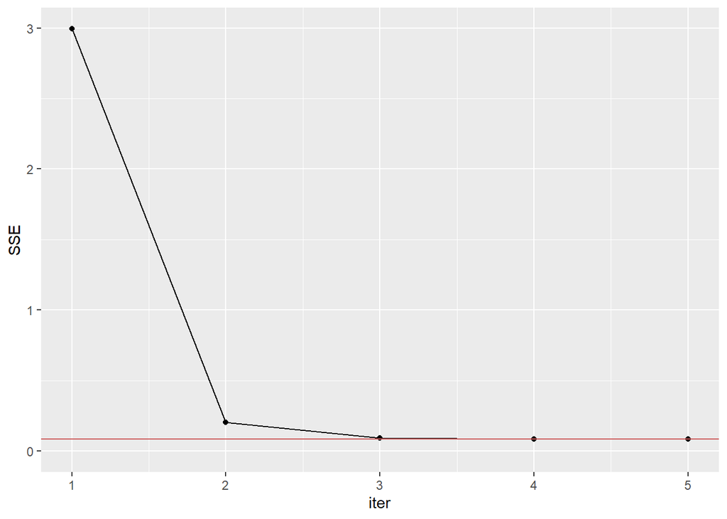

```r
p = 100
n = 1000

X = matrix(rnorm(n * p), ncol = p)
beta = rnorm(p)
Y = X %*% beta + rnorm(n)

beta_hat = rep(0, p)
num_iter = 5

# Stores the coefficients at each iteration
beta_hat_mat = matrix(0, nrow = num_iter, ncol = p)

for (i in 1:num_iter) {
  for (j in 1:p) {

    residual = Y - X[, -j] %*% beta_hat[-j]

    beta_hat[j] = lm(residual ~ X[, j])$coef[2]
  }

  beta_hat_mat[i, ] = beta_hat
}

# Sum of Squared Errors from the real vector of coefficients
error = apply(beta_hat_mat, 1, function(b) sum((b - beta)^2))

df = data.frame("SSE"=unlist(error),
                "iter"=1:length(error))

MLE_fit = lm(Y ~ X)
MLE_error = sum((MLE_fit$coefficients[-1] - beta)^2)

df %>% ggplot(aes(x=iter, y=SSE)) + geom_point() + geom_line() +
  geom_hline(yintercept=MLE_error, col="indianred") + ylim(c(0, NA))
```

The algorithm converges after just a few iteration to the same value for $\hat{\beta}$ obtained via ML estimation, whose error is represented in the plot by the red line.